# data viz concepts

2022-10-21

Data Visualization Concepts (20 points)

Topics to Cover:

Grammar of Graphics.

One topic from the Data Visualization Reading of your choice.

A second topic from the Data Visualization Reading of your choice.

Make sure to include:

(4 points) An introductory statement with the goal of the section (in your own words) and a brief description of the data set and variables you will be using.

(16 points) R code chunks interspersed with some text descriptions about the code you have written and with text description about each topic. All three topics should have some R code. The data you use can be real data or it can be “toy” data (generated from tibble()).

you do not need to cover everything in these topics: aim for writing something that someone would be able to read through in ~ 10 minutes.

This will demonstrate the basics of data visualization – the Grammar of Graphics (possible functions) and best practices for successful visualizations, including color and channels of visualizations. I will use a gun violence data set which looks at mortality and ownership rates of guns by state and region in America.

```r
library(tidyverse)
guns <- read_csv("data/gun_violence_us.csv")
```

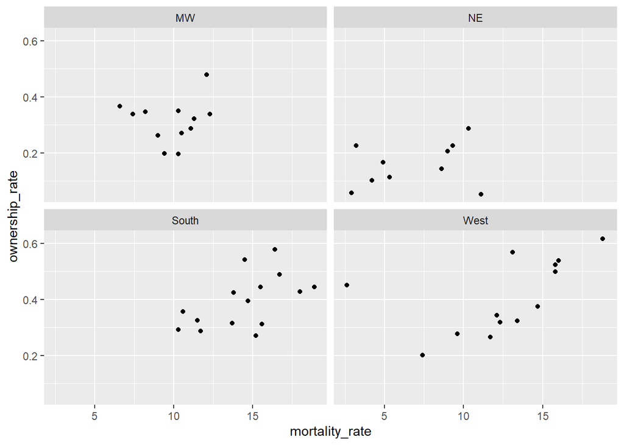

```r
ggplot(data = guns, aes(x = ownership_rate, y = mortality_rate)) +
  geom_point(stat ="identity", position = "identity") +
  coord_flip() +
  facet_wrap(~region)
```

Sequential (least to most), diverging (two opposites with neutral in middle), and unordered are three possible color palattes.

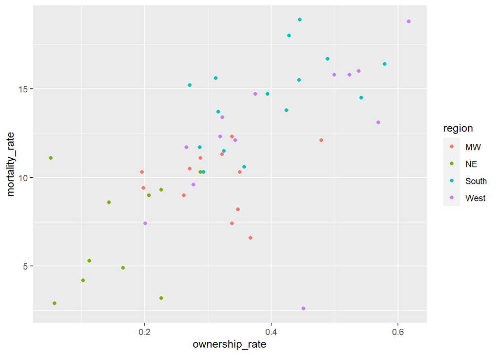

```r
ggplot(data = guns, aes(x = ownership_rate, y = mortality_rate, color = region)) +
  geom_point()
```

Here unordered is used since we have four distinct categorical variables.

There are myriad channels for mapping data. For unordered categorical variables, as we saw above, the four most effective modes of visualization in order of effectiveness are position in space, color, motion, and shape. Above we used color to differentiate between the regions. See how it is more effective than if it were by shape, as below:

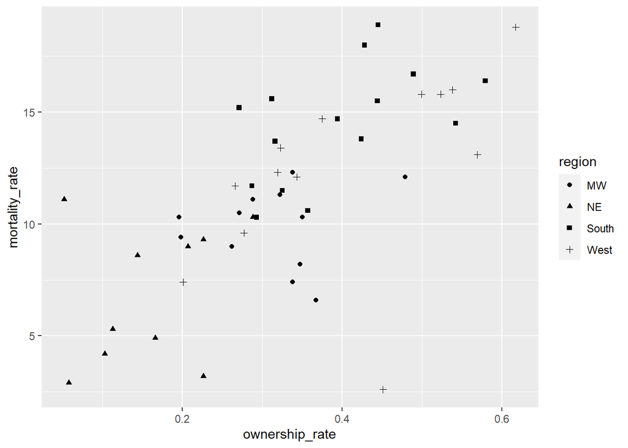

```r
ggplot(data = guns, aes(x = ownership_rate, y = mortality_rate, shape = region)) +
  geom_point()
```